# Class 17: Vaccination Rate Mini Project

Tasnia Sharia (PID A15931128)

11/23/2021

# Background

The goal of this hands-on mini-project is to examine and compare the Covid-19 vaccination rates around San Diego.

We will take data from the CA state gov website to retrieve our data: https://data.ca.gov/dataset/covid-19-vaccine-progress-dashboard-data-by-zip-code

# Getting Started

```r
# Import vaccination data
vax <- read.csv("covid19vaccinesbyzipcode_test.csv")
head(vax)
```

```
##   as_of_date zip_code_tabulation_area local_health_jurisdiction    county
## 1 2021-01-05                    92804                    Orange    Orange
## 2 2021-01-05                    92626                    Orange    Orange
## 3 2021-01-05                    92250                  Imperial  Imperial
## 4 2021-01-05                    92637                    Orange    Orange
## 5 2021-01-05                    92155                 San Diego San Diego
## 6 2021-01-05                    92259                  Imperial  Imperial
##   vaccine_equity_metric_quartile                 vem_source
## 1                              2 Healthy Places Index Score
## 2                              3 Healthy Places Index Score
## 3                              1 Healthy Places Index Score
## 4                              3 Healthy Places Index Score
## 5                             NA            No VEM Assigned
## 6                              1    CDPH-Derived ZCTA Score
##   age12_plus_population age5_plus_population persons_fully_vaccinated
```

[output cut: 34 more lines]

> **Q1. What column details the total number of people fully vaccinated?**

```r
#vax$persons_fully_vaccinated

#hiding the output so it does not take up s many pages when submitting
```

“persons_fully_vaccinated” column details the total number of people fully vaccinated

> **Q2. What column details the Zip code tabulation area?**

```r
#vax$zip_code_tabulation_area

#hiding the output so it does not take up s many pages when submitting
```

“zip_code_tabulation_area” details the Zip code tabulation area.

> **Q3. What is the earliest date in this dataset?**

```r
head(vax$as_of_date)
```

```
## [1] "2021-01-05" "2021-01-05" "2021-01-05" "2021-01-05" "2021-01-05"
## [6] "2021-01-05"
```

January 5, 2021 is the earliest data

> **Q4. What is the latest date in this dataset?**

```r
tail(vax$as_of_date)
```

```
## [1] "2021-11-16" "2021-11-16" "2021-11-16" "2021-11-16" "2021-11-16"
## [6] "2021-11-16"
```

November 16, 2021 is the latest date

```r
#getting quick overview of the dataset
#had to install skimr package
skimr::skim(vax)
```

Data summary

| Name | vax |
| --- | --- |
| Number of rows | 81144 |
| Number of columns | 14 |
| _______________________ |  |
| Column type frequency: |  |
| character | 5 |
| numeric | 9 |
| ________________________ |  |
| Group variables | None |

**Variable type: character**

| skim_variable | n_missing | complete_rate | min | max | empty | n_unique | whitespace |
| --- | --- | --- | --- | --- | --- | --- | --- |
| as_of_date | 0 | 1 | 10 | 10 | 0 | 46 | 0 |
| local_health_jurisdiction | 0 | 1 | 0 | 15 | 230 | 62 | 0 |
| county | 0 | 1 | 0 | 15 | 230 | 59 | 0 |
| vem_source | 0 | 1 | 15 | 26 | 0 | 3 | 0 |
| redacted | 0 | 1 | 2 | 69 | 0 | 2 | 0 |

**Variable type: numeric**

| skim_variable | n_missing | complete_rate | mean | sd | p0 | p25 | p50 | p75 | p100 | hist |
| --- | --- | --- | --- | --- | --- | --- | --- | --- | --- | --- |
| zip_code_tabulation_area | 0 | 1.00 | 93665.11 | 1817.39 | 90001 | 92257.75 | 93658.50 | 95380.50 | 97635.0 | ▃▅▅▇▁ |
| vaccine_equity_metric_quartile | 4002 | 0.95 | 2.44 | 1.11 | 1 | 1.00 | 2.00 | 3.00 | 4.0 | ▇▇▁▇▇ |
| age12_plus_population | 0 | 1.00 | 18895.04 | 18993.94 | 0 | 1346.95 | 13685.10 | 31756.12 | 88556.7 | ▇▃▂▁▁ |
| age5_plus_population | 0 | 1.00 | 20875.24 | 21106.05 | 0 | 1460.50 | 15364.00 | 34877.00 | 101902.0 | ▇▃▂▁▁ |
| persons_fully_vaccinated | 8256 | 0.90 | 9456.49 | 11498.25 | 11 | 506.00 | 4105.00 | 15859.00 | 71078.0 | ▇▂▁▁▁ |
| persons_partially_vaccinated | 8256 | 0.90 | 1900.61 | 2113.07 | 11 | 200.00 | 1271.00 | 2893.00 | 20185.0 | ▇▁▁▁▁ |
| percent_of_population_fully_vaccinated | 8256 | 0.90 | 0.42 | 0.27 | 0 | 0.19 | 0.44 | 0.62 | 1.0 | ▇▆▇▆▂ |
| percent_of_population_partially_vaccinated | 8256 | 0.90 | 0.10 | 0.10 | 0 | 0.06 | 0.07 | 0.11 | 1.0 | ▇▁▁▁▁ |
| percent_of_population_with_1_plus_dose | 8256 | 0.90 | 0.50 | 0.26 | 0 | 0.30 | 0.53 | 0.70 | 1.0 | ▅▅▇▇▃ |

> **Q5. How many numeric columns are in this dataset?**

There are 9 numeric columns.

> **Q6. Note that there are “missing values” in the dataset. How many NA values there in the persons_fully_vaccinated column?**

There are 8256 NA values in the persons_fully_vaccinated column.

> **Q7. What percent of persons_fully_vaccinated values are missing (to 2 significant figures)?**

```r
8256/81144 * 100
```

```
## [1] 10.1745
```

10.17% of persons fully vaccinated values are missing.

> ** [Optional]: Why might this data be missing?**

Many people chose to not get vaccinated or felt that the first dose is effective enough.

**Working with Dates**

The lubridate packages can make working with dates and times a lot easier.

```r
#had to install the lubridate package
#loading the library
library(lubridate)
#what is the date today
today()
```

```
## [1] "2021-11-29"
```

```r
# Specify that we are using the Year-month-day format easier for the lubridate package
vax$as_of_date <- ymd(vax$as_of_date)
```

```r
today() - vax$as_of_date[1]
```

```
## Time difference of 328 days
```

```r
#We can now determine how many days the dataset span
vax$as_of_date[nrow(vax)] - vax$as_of_date[1]
```

```
## Time difference of 315 days
```

> **Q9. How many days have passed since the last update of the dataset?**

```r
today() - vax$as_of_date[81144]
```

```
## Time difference of 13 days
```

> **Q10. How many unique dates are in the dataset (i.e. how many different dates are detailed)?**

```r
length(unique(vax$as_of_date))
```

```
## [1] 46
```

# Working with Zip Codes

We can use the zipcodeR package to make working with zip code column easier

```r
#had to install zipcodeR package
#loading library
library(zipcodeR)
geocode_zip('92037')
```

```
## # A tibble: 1 x 3
##   zipcode   lat   lng
##   <chr>   <dbl> <dbl>
## 1 92037    32.8 -117.
```

```r
#Calculating the distance between the center of any two ZIP codes in miles
zip_distance('92037','92109')
```

```
##   zipcode_a zipcode_b distance
## 1     92037     92109     2.33
```

```r
#can pull census data about ZIP code areas (like median household income)
reverse_zipcode(c('92037', "92109") )
```

```
## # A tibble: 2 x 24
##   zipcode zipcode_type major_city post_office_city common_city_list county state
##   <chr>   <chr>        <chr>      <chr>                      <blob> <chr>  <chr>
## 1 92037   Standard     La Jolla   La Jolla, CA           <raw 20 B> San D~ CA
## 2 92109   Standard     San Diego  San Diego, CA          <raw 21 B> San D~ CA
## # ... with 17 more variables: lat <dbl>, lng <dbl>, timezone <chr>,
## #   radius_in_miles <dbl>, area_code_list <blob>, population <int>,
## #   population_density <dbl>, land_area_in_sqmi <dbl>,
## #   water_area_in_sqmi <dbl>, housing_units <int>,
## #   occupied_housing_units <int>, median_home_value <int>,
## #   median_household_income <int>, bounds_west <dbl>, bounds_east <dbl>,
## #   bounds_north <dbl>, bounds_south <dbl>
```

```r
#pulling data for all ZIP codes in the dataset
zipdata <- reverse_zipcode( vax$zip_code_tabulation_area )
```

# Focus on the San Diego area

We will focus on the San Diego County area by referring to vax$county == “San Diego” entries.

```r
# Subset to San Diego county only areas using R code
#sd <- vax[vax$county == "San Diego", ]
```

```r
#or we can use the dplyr package which is more convenient when we are subsetting across multiple criteria
library(dplyr)
sd <- filter(vax, county == "San Diego")
nrow(sd)
```

```
## [1] 4922
```

> **Q11. How many distinct zip codes are listed for San Diego County?**

```r
length(unique(sd$zip_code_tabulation_area))
```

```
## [1] 107
```

> **Q12. What San Diego County Zip code area has the largest 12 + Population in this dataset?**

```r
ind <- which.max(sd$age12_plus_population)
sd[ind,]
```

```
##    as_of_date zip_code_tabulation_area local_health_jurisdiction    county
## 23 2021-01-05                    92154                 San Diego San Diego
##    vaccine_equity_metric_quartile                 vem_source
## 23                              2 Healthy Places Index Score
##    age12_plus_population age5_plus_population persons_fully_vaccinated
## 23               76365.2                82971                       32
##    persons_partially_vaccinated percent_of_population_fully_vaccinated
## 23                         1336                               0.000386
##    percent_of_population_partially_vaccinated
## 23                                   0.016102
##    percent_of_population_with_1_plus_dose redacted
## 23                               0.016488       No
```

> **Q13. What is the overall average “Percent of Population Fully Vaccinated” value for all San Diego “County” as of “2021-11-09”?**

```r
sd.row <- filter(sd, as_of_date=="2021-11-09")
mean(sd.row$percent_of_population_fully_vaccinated, na.rm=TRUE)
```

```
## [1] 0.6727567
```

The overall average is 67.3%

> **Q14. Using either ggplot or base R graphics make a summary figure that shows the distribution of Percent of Population Fully Vaccinated values as of “2021-11-09”?**

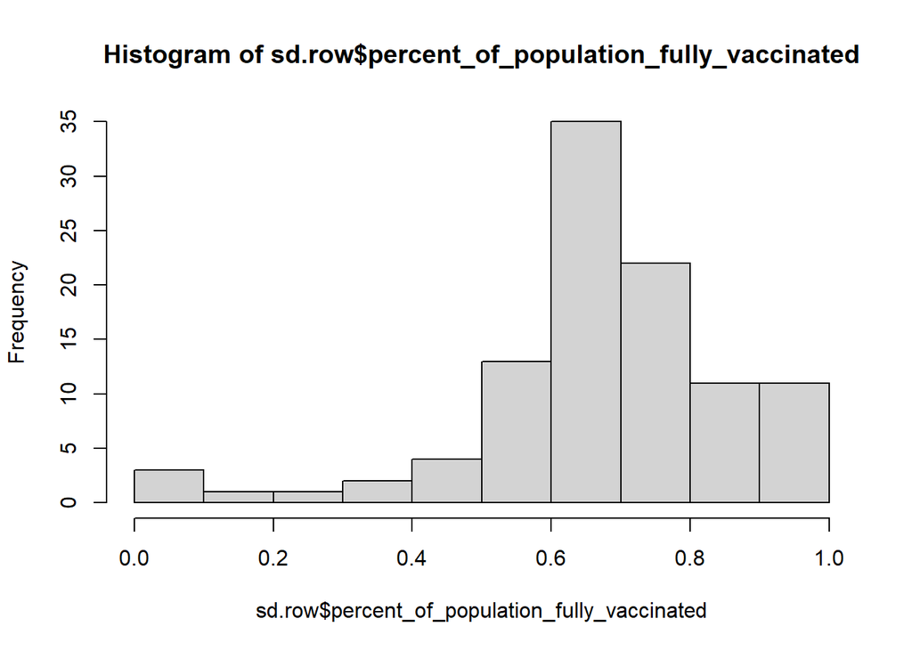

```r
hist(sd.row$percent_of_population_fully_vaccinated)
```

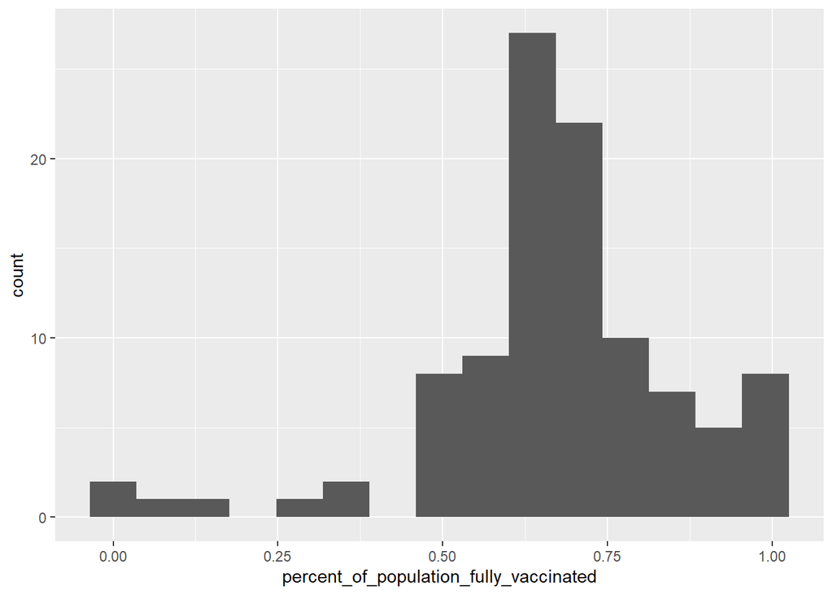

```r
#making a plot using ggplot
#loading library
library(ggplot2)

ggplot(sd.row) + aes(percent_of_population_fully_vaccinated) + geom_histogram(bins=15)
```

# Focus on UCSD/La Jolla

```r
ucsd <- filter(sd, zip_code_tabulation_area=="92037")
ucsd[1,]$age5_plus_population
```

```
## [1] 36144
```

> **Q15. Using ggplot make a graph of the vaccination rate time course for the 92037 ZIP code area:**

```r
filter(sd.row, zip_code_tabulation_area=="92037")
```

```
##   as_of_date zip_code_tabulation_area local_health_jurisdiction    county
## 1 2021-11-09                    92037                 San Diego San Diego
##   vaccine_equity_metric_quartile                 vem_source
## 1                              4 Healthy Places Index Score
##   age12_plus_population age5_plus_population persons_fully_vaccinated
## 1               33675.6                36144                    32859
##   persons_partially_vaccinated percent_of_population_fully_vaccinated
## 1                         6354                               0.909114
##   percent_of_population_partially_vaccinated
## 1                                   0.175797
##   percent_of_population_with_1_plus_dose redacted
## 1                                      1       No
```

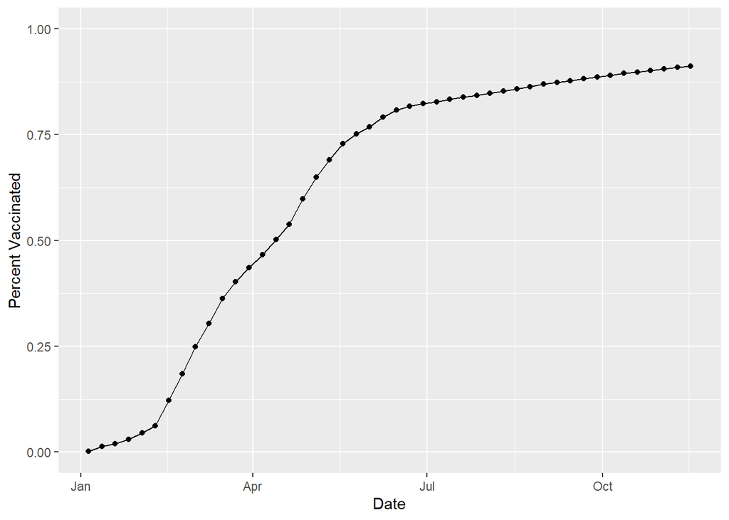

```r
ggplot(ucsd) +
  aes(as_of_date,
      percent_of_population_fully_vaccinated) +
  geom_point() +
  geom_line(group=1) +
  ylim(c(0,1)) +
  labs(x="Date", y="Percent Vaccinated")
```

Population in the 92037 ZIP code area

```r
ucsd[1,]$age5_plus_population
```

```
## [1] 36144
```

# Comparing 92037 to other similar sized areas?

Looking across every zip code area with a population at least as large as that of 92037 on as_of_date “2021-11-16”

```r
# Subset to all CA areas with a population as large as 92037
vax.36 <- filter(vax, age5_plus_population > 36144 &
                as_of_date == "2021-11-16")

#head(vax.36)
```

> **Q16. Calculate the mean “Percent of Population Fully Vaccinated” for ZIP code areas with a population as large as 92037 (La Jolla) as_of_date “2021-11-16”. Add this as a straight horizontal line to your plot from above with the geom_hline() function?**

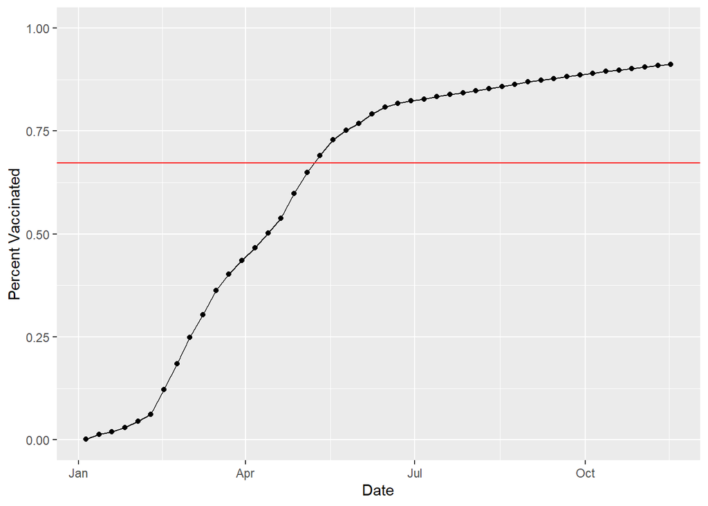

```r
ggplot(ucsd) +
  aes(as_of_date,
      percent_of_population_fully_vaccinated) +
  geom_point() +
  geom_line(group=1) +
  geom_hline(yintercept = 0.67276, color="red") +
  ylim(c(0,1)) +
  labs(x="Date", y="Percent Vaccinated")
```

> **Q17. What is the 6 number summary (Min, 1st Qu., Median, Mean, 3rd Qu., and Max) of the “Percent of Population Fully Vaccinated” values for ZIP code areas with a population as large as 92037 (La Jolla) as_of_date “2021-11-16”?**

```r
summary(vax.36$percent_of_population_fully_vaccinated)
```

```
##    Min. 1st Qu.  Median    Mean 3rd Qu.    Max.
##  0.3519  0.5891  0.6649  0.6630  0.7286  1.0000
```

> **Q18. Using ggplot generate a histogram of this data.**

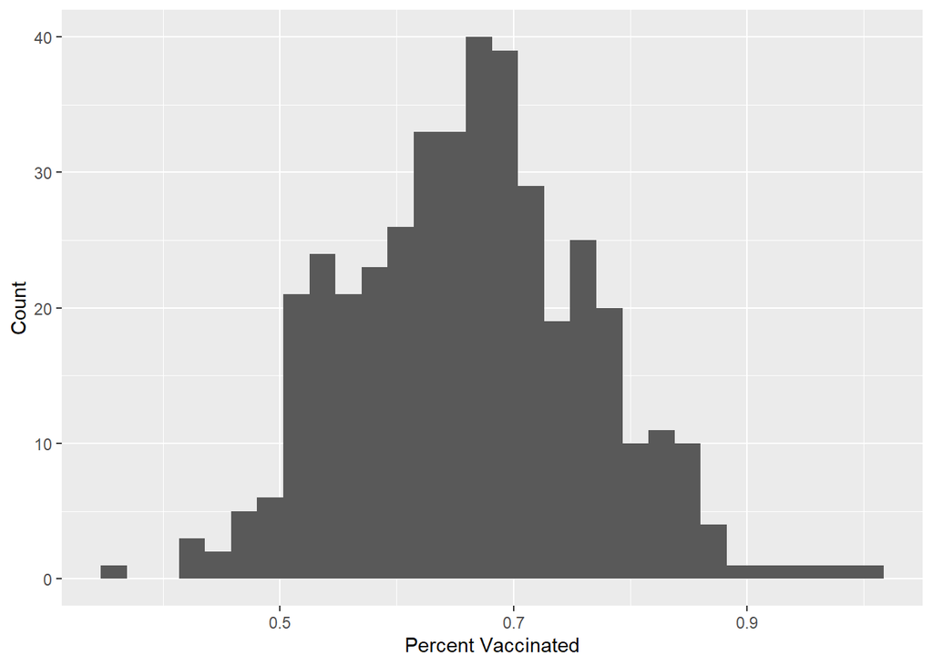

```r
ggplot(vax.36) + aes(percent_of_population_fully_vaccinated) + geom_histogram() + labs(x="Percent Vaccinated", y="Count")
```

> **Q19. Is the 92109 and 92040 ZIP code areas above or below the average value you calculated for all these above?**

```r
vax %>% filter(as_of_date == "2021-11-16") %>%
  filter(zip_code_tabulation_area=="92040") %>%
  select(percent_of_population_fully_vaccinated)
```

```
##   percent_of_population_fully_vaccinated
## 1                               0.520463
```

```r
vax %>% filter(as_of_date == "2021-11-16") %>%
  filter(zip_code_tabulation_area=="92109") %>%
  select(percent_of_population_fully_vaccinated)
```

```
##   percent_of_population_fully_vaccinated
## 1                               0.687763
```

The zip code 92040 is below the average and the zip code 92109 is above average.

> **Q20. Finally make a time course plot of vaccination progress for all areas in the full dataset with a age5_plus_population > 36144.**

```r
vax.36.all <- filter(vax, age5_plus_population > 36144)
```

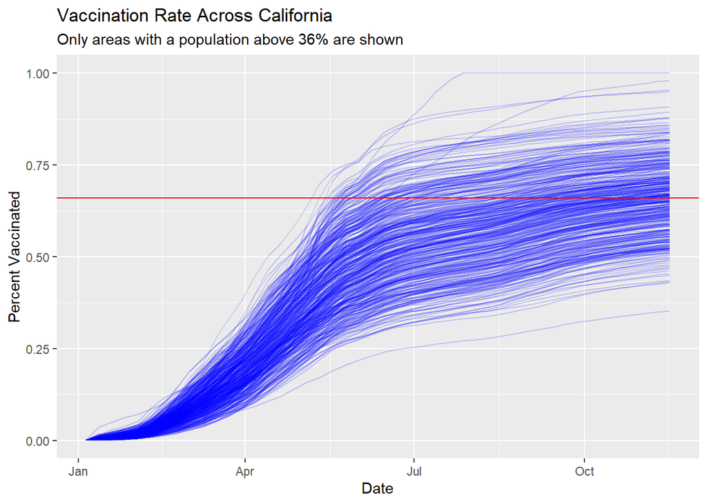

```r
ggplot(vax.36.all) +
  aes(as_of_date,
      percent_of_population_fully_vaccinated,
      group=zip_code_tabulation_area) +
  geom_line(alpha=0.2, color="blue") +
  labs(x="Date", y="Percent Vaccinated",
       title="Vaccination Rate Across California",
       subtitle="Only areas with a population above 36% are shown") +
  geom_hline(yintercept = 0.66, col="red")
```

> **Q21. How do you feel about traveling for Thanksgiving and meeting for in-person class next Week?**

Many students would travel during the break. It would be safer is classes were remote afterwards.